# Team

# Info

Names: Devin Erb, Alex Thompson

Github info,

Link: https://github.com/satdragon/ds202_lab2

Username: satdragon

Repo Name: ds202_lab2

## Questions

**Reading the data in**

```r
choco <- read.csv("https://raw.githubusercontent.com/lbchu/ds202_labs/master/choco.csv")
```

**1) Run the following code line by line to figure out what it’s doing. Then next to each line of code, write a comment explaining its purpose and function, including the use of any specific arguments. Comments in R are proceeded by a #, so that R knows not to run anything after the hashtag.**

```r
recent_rating = choco[choco$Review.Date>2011,]
# This line is creating a new datafram out of columns who's review date is greater than 2011.
```

```r
unique(recent_rating$Company.Location)
```

```
##  [1] France            U.S.A.            Netherlands
##  [4] Brazil            Russia            Peru
##  [7] Canada            Italy             U.K.
## [10] Australia         Wales             Germany
## [13] Belgium           Spain             Puerto Rico
## [16] Venezuela         Colombia          Japan
## [19] New Zealand       Costa Rica        South Korea
## [22] Amsterdam         Scotland          Martinique
## [25] Guatemala         South Africa      St. Lucia
## [28] Portugal          Singapore         Denmark
## [31] Ecuador           Israel            Switzerland
## [34] India             Czech Republic    Domincan Republic
## [37] Finland           Philippines       Sweden
## [40] Poland            Vietnam           Austria
## [43] Madagascar        Honduras          U.A.E.
## [46] Lithuania         Nicaragua         Niacragua
## [49] Chile             Iceland           Mexico
## [52] Hungary           Suriname          Ireland
## 61 Levels: Amsterdam Argentina Australia Austria Belgium ... Wales
```

```r
# This line is listing all the unique locations from the recent_rating dataframe and storing them in levels.
```

```r
recent_rating$Company.Location = droplevels(recent_rating$Company.Location)
#This is removing the unused levels from the location column of the recent_rating frame.
```

```r
head(recent_rating)
```

```
##    Company Specific.Bean.Origin  REF Review.Date Cocoa.Pct
## 1 A. Morin          Agua Grande 1876        2016        63
## 2 A. Morin                Kpime 1676        2015        70
## 3 A. Morin               Panama 1011        2013        70
## 4 A. Morin           Madagascar 1011        2013        70
## 5 A. Morin               Brazil 1011        2013        70
## 6 A. Morin             Equateur 1011        2013        70
##   Company.Location Rating Bean.Type Broad.Bean.Origin
## 1           France   3.75                    Sao Tome
## 2           France   2.75                        Togo
## 3           France   2.75                      Panama
## 4           France   3.00   Criollo        Madagascar
## 5           France   3.25                      Brazil
## 6           France   3.75                     Ecuador
```

```r
# This displays the top of the recent_rating table
```

```r
cross_table = table(recent_rating$Review.Date,recent_rating$Company.Location)
cross_table
```

```
##
##        Amsterdam Australia Austria Belgium Brazil Canada Chile Colombia
##   2012         0         8      11       0      3      8     0        1
##   2013         0         4       0       4      5     18     0        0
##   2014         0         8       1       2      0     33     0        5
##   2015         4        12       0       4      3     18     2        1
##   2016         0        11       9       0      2     18     0        7
##   2017         2         2       1       0      1     13     0        0
##
##        Costa Rica Czech Republic Denmark Domincan Republic Ecuador Finland
##   2012          2              0       4                 0       2       0
##   2013          2              0       2                 5       0       0
##   2014          0              0       1                 0       7       1
##   2015          5              1       2                 0       3       0
##   2016          0              0       3                 0       1       1
```

[output cut: 49 more lines]

```r
#This line is showing how many times each unique location showed up in a given year in a cross table format.
```

```r
which(cross_table[1,]!=0 & cross_table[2,]!=0 & cross_table[3,]!=0 & cross_table[4,]!=0 & cross_table[5,]!=0)
```

```
## Australia    Canada   Denmark    France   Germany      U.K.    U.S.A.
##         2         6        11        15        16        50        51
```

```r
#This line is shwoing which locations had an entry for ever single year.
```

```r
france_recent = subset(recent_rating,Company.Location =='France')
uk_recent = subset(recent_rating,Company.Location =='U.K.')
germany_recent = subset(recent_rating,Company.Location=='Germany')
# These lines are pulling the subset of the data for france, gemany, and the uk from the recent ratings list and putting them in their own subset dataframe.
```

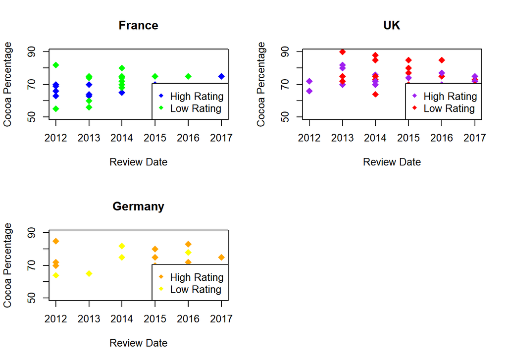

```r
par(mfrow=c(2,2))
color1 = ifelse(france_recent$Rating >median(france_recent$Rating), 'blue', 'green')
plot(france_recent$Cocoa.Pct ~ france_recent$Review.Date,ylim=c(50,90),col=color1,pch=18,cex=1.5,xlab="Review Date", ylab= "Cocoa Percentage", main= "France")
legend('bottomright',legend=c('High Rating', 'Low Rating'),col=c('blue','green'),pch=18)

color2 = ifelse(uk_recent$Rating >median(uk_recent$Rating), 'purple', 'red')
plot(uk_recent$Cocoa.Pct ~ uk_recent$Review.Date,ylim=c(50,90),col=color2,pch=18,cex=1.5, xlab="Review Date", ylab= "Cocoa Percentage", main= "UK")
legend('bottomright',legend=c('High Rating', 'Low Rating'),col=c('purple','red'),pch=18)

color3 = ifelse(germany_recent$Rating > median(germany_recent$Rating), 'orange', 'yellow')
plot(germany_recent$Cocoa.Pct ~ germany_recent$Review.Date,ylim=c(50,90),col=color3,pch=18,cex=1.5,xlab="Review Date", ylab= "Cocoa Percentage", main= "Germany")
legend('bottomright',legend=c('High Rating', 'Low Rating'),col=c('orange','yellow'),pch=18)

# These line are all generating a plot that shows all the points of data for each location in a chart of year vs. cocoa percentage, and then the high and low ratings for the review highlighted in different colors.
```

**2) Click Zoom on the Rstudio window (under Plots) to see the plot more clearly. How do you think the plot produced from the code above can be improved? Recommend at least one possible improvement.**

At least on my knitting of the code it appears that the legend for the data is covering the data points. I think it would be good to pass some arguments to position the legend in a better position.

**3) How does the number of ratings (not the actual value of the rating) depend on the year? Use graphics to answer this question.**

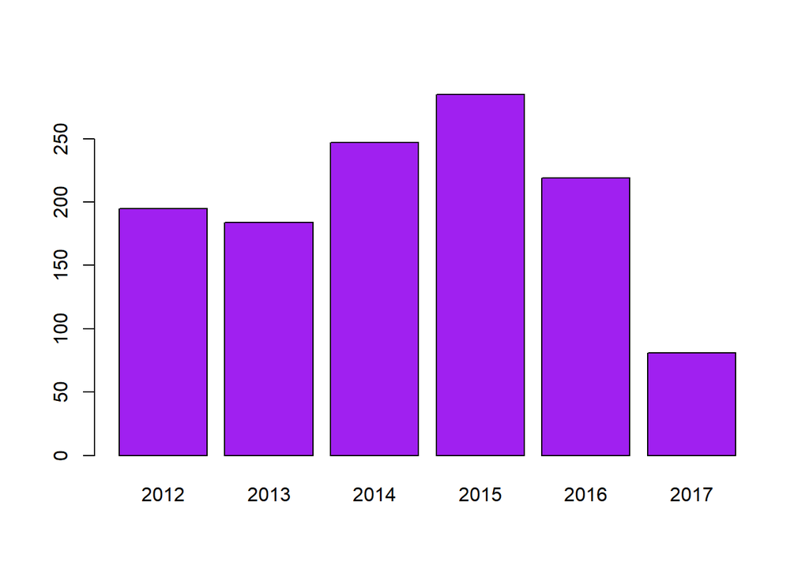

```r
x = table(recent_rating$Review.Date)
barplot(x, col = 'purple')
```

As the year approaches 2015 the trend increases, then sharply decreases as it goes to 2017.

**4) How do ratings compare across different company locations? Focus on the three locations with the most ratings. Hint: the function `sort()` might come in handy here.**

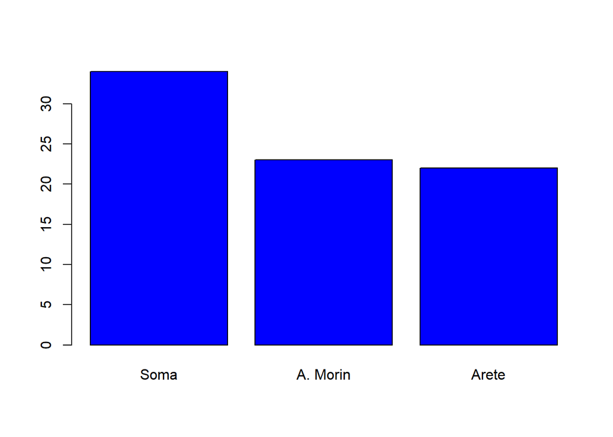

```r
top3 = head(rev(sort(table(recent_rating$Company))), 3)
barplot(top3, col = 'blue')
```

**5) Brainstorm and write down an interesting question that can be answer from the dataset. The question should not duplicate the questions above.**

One question that we could ask is which ratings are the most common.

**6) Bonus points (optional): Answer the question from the dataset.**

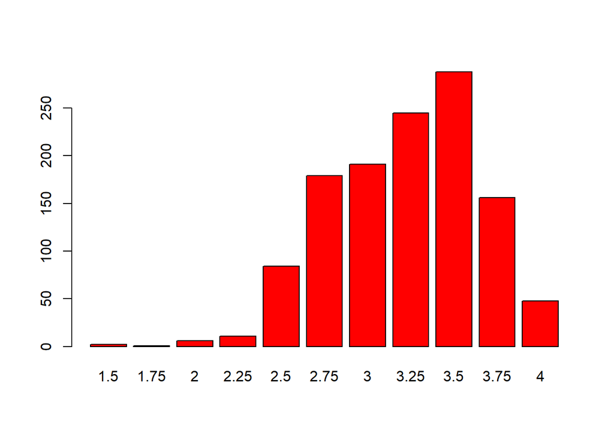

```r
topratings = table(recent_rating$Rating)
barplot(topratings, col = 'red')
```